# Brain Stroke Prediction

# 1 Introduction

This paper continues our discussion on [Brain Stroke Prediction](https://www.kaggle.com/datasets/fedesoriano/stroke-prediction-dataset). Stroke is one of the leading causes of death and disability in the USA. Given this context our basic SMART question remains the same: What are the most accurate predictors of the likelihood of having a brain stroke? This results to be a classification problem on the target variable of having a stroke, and we will apply 3 different approaches and imbalance techniques learned throughout the course to try to solve it.

Included in our discussion is some Exploratory Data Analysis (EDA) from our first assignment, along with some new models, including Logistic Regression, Decision Tree Classifier, and Random Forest Classifier.

# 2 Exploratory Data Analysis

The following are excerpts and graphs from the EDA section of our previous report. We are including them here to remind the reader of our dataset’s attributes, before we dive into the analysis.

```
## 'data.frame':    5110 obs. of  12 variables:
##  $ id               : int  9046 51676 31112 60182 1665 56669 53882 10434 27419 60491 ...
##  $ gender           : chr  "Male" "Female" "Male" "Female" ...
##  $ age              : num  67 61 80 49 79 81 74 69 59 78 ...
##  $ hypertension     : int  0 0 0 0 1 0 1 0 0 0 ...
##  $ heart_disease    : int  1 0 1 0 0 0 1 0 0 0 ...
##  $ ever_married     : chr  "Yes" "Yes" "Yes" "Yes" ...
##  $ work_type        : chr  "Private" "Self-employed" "Private" "Private" ...
##  $ Residence_type   : chr  "Urban" "Rural" "Rural" "Urban" ...
##  $ avg_glucose_level: num  229 202 106 171 174 ...
##  $ bmi              : chr  "36.6" "N/A" "32.5" "34.4" ...
##  $ smoking_status   : chr  "formerly smoked" "never smoked" "never smoked" "smokes" ...
##  $ stroke           : int  1 1 1 1 1 1 1 1 1 1 ...
```

Out of 5110 observations, we can see there are 4860 no stroke observations, while there are 250 stroke observations.

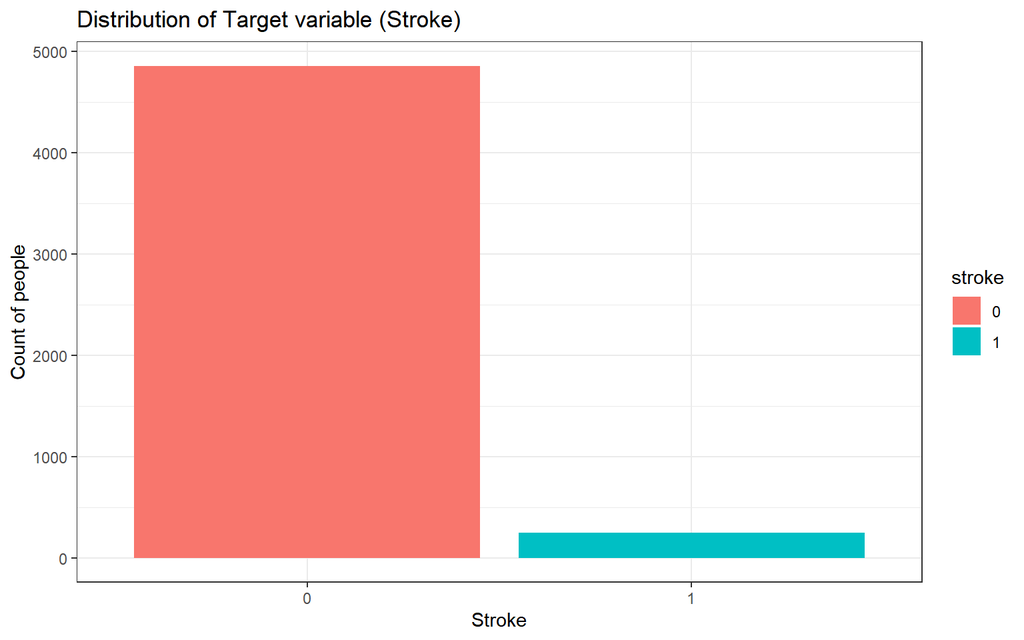

## 2.1 Important Features Comparisions

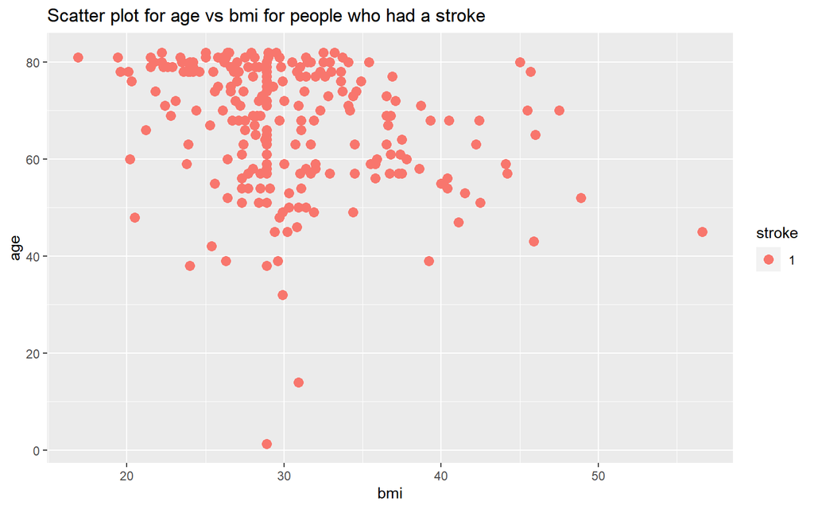

From the scatterplot it is evident that most of the data points fall between the BMI range of 25-35 which is categorized as overweight and obese.

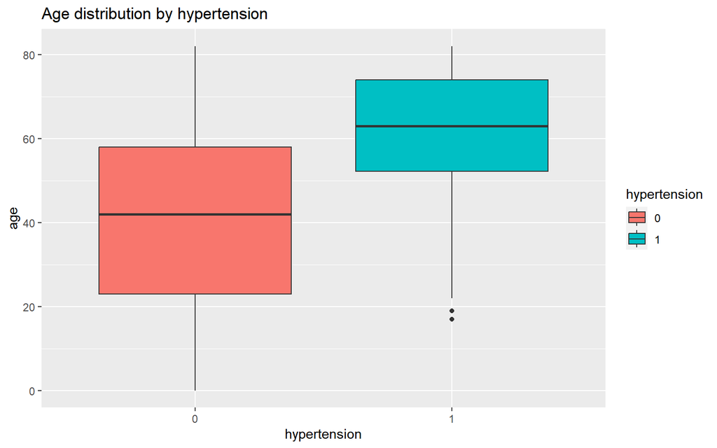

From the boxplot we can see that as age increases the chances of having Hypertension also increases, which can lead to an individual having a stroke.

# 3 Modeling Techniques

## 3.1 Addressing the imbalance issue in the dataset

A dataset is said to be imbalanced when the number of observations per class is not equally distributed among the training dataset. There has been a heavy class imbalance in our dataset as mentioned above.

To reduce the imbalance dataset two sampling methods were performed. They are:

**ROSE (Random OverSampler Examples)**

**Combination of Under and Over sampling**

## 3.2 Feature Selection

Random forest model is considered for feature selection. It consists of 4-12 hundred trees, each of them built over a random extraction of the characteristics within the dataset, and a random extraction of the features. Because some trees don’t see all the features or all the observations, the trees are guaranteed to be de-correlated and consequently less likely to overfit. Every tree also consists of a series of yes-or-no questions depending on a single or several attributes. The dataset is split into two buckets at each node by the tree, with each bucket containing observations that are more similar to one another and distinct from those in the other bucket. The significance of each attribute is therefore determined by how “pure” each of the buckets is.

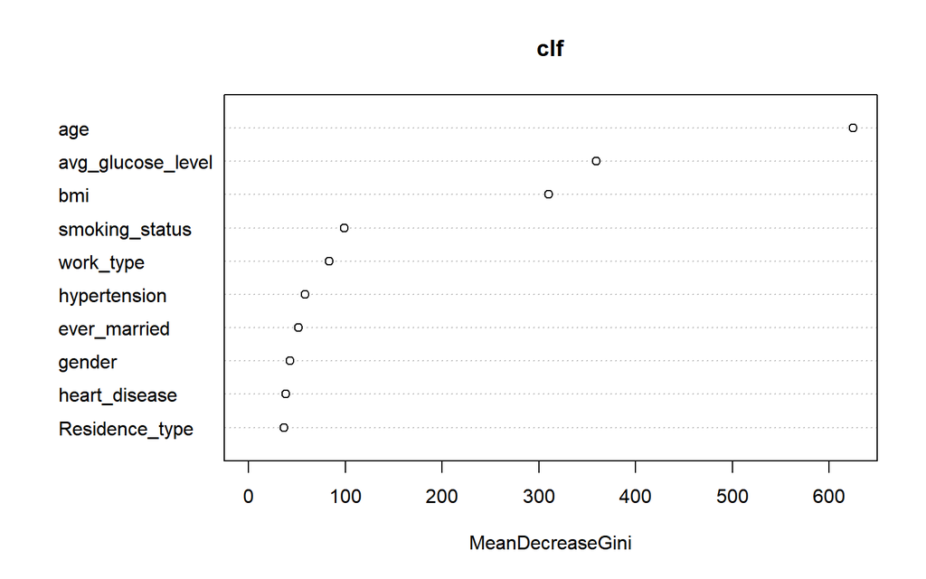

## 3.3 BOTH - Under and Over Sampling Technique.

Both Under and Oversampling Technique is combined.Undersampling is a technique to balance uneven datasets by keeping all of the data in the minority class and decreasing the size of the majority class. oversampling involves randomly selecting examples from the minority class, with replacement, and adding them to the training dataset.

### 3.3.1 Logistic Regression - BOTH

Logit is a type of generalized linear model (GLiM) that uses statistical analysis to predict an event based on known factors when using a dichotomous dependent variable. In the logit model the log odds of the outcome is modeled as a linear combination of the predictor variables.

```
## Confusion Matrix and Statistics
##
##           Reference
## Prediction    0    1
##          0 1085   10
##          1  374   58
##
##                Accuracy : 0.749
##                  95% CI : (0.726, 0.77)
##     No Information Rate : 0.955
##     P-Value [Acc > NIR] : 1
##
##                   Kappa : 0.168
##
##  Mcnemar's Test P-Value : <0.0000000000000002
##
##             Sensitivity : 0.744
##             Specificity : 0.853
##          Pos Pred Value : 0.991
##          Neg Pred Value : 0.134
##               Precision : 0.991
##                  Recall : 0.744
##                      F1 : 0.850
##              Prevalence : 0.955
##          Detection Rate : 0.711
##    Detection Prevalence : 0.717
##       Balanced Accuracy : 0.798
##
##        'Positive' Class : 0
##
```

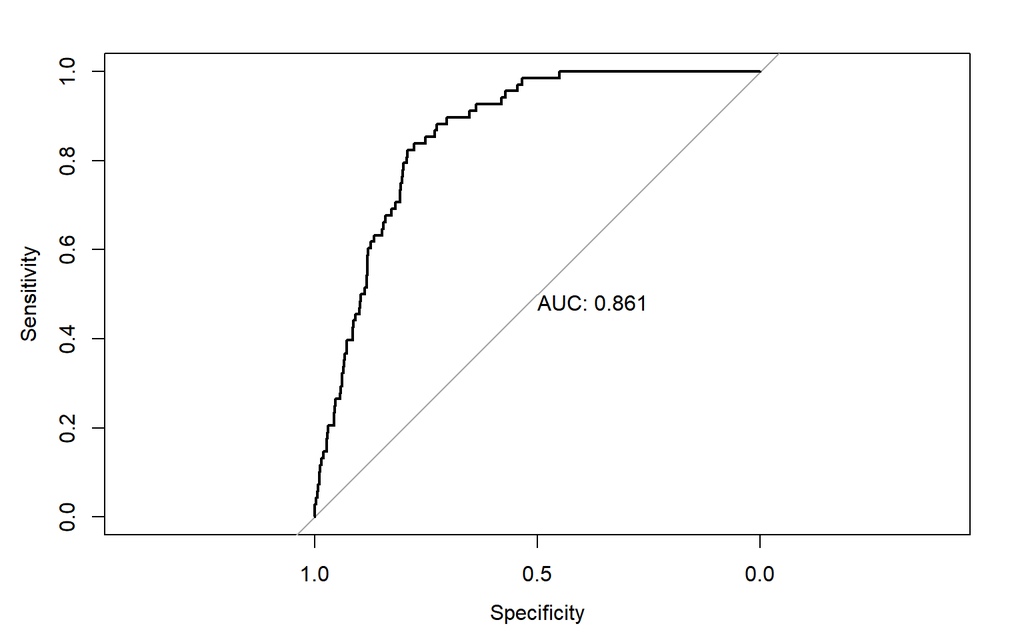

### 3.3.2 Logistic Regression with feature selected variables - BOTH

```
## Confusion Matrix and Statistics
##
##           Reference
## Prediction    0    1
##          0 1072   10
##          1  387   58
##
##                Accuracy : 0.74
##                  95% CI : (0.717, 0.762)
##     No Information Rate : 0.955
##     P-Value [Acc > NIR] : 1
##
##                   Kappa : 0.161
##
##  Mcnemar's Test P-Value : <0.0000000000000002
##
##             Sensitivity : 0.735
##             Specificity : 0.853
##          Pos Pred Value : 0.991
##          Neg Pred Value : 0.130
##               Precision : 0.991
##                  Recall : 0.735
##                      F1 : 0.844
##              Prevalence : 0.955
##          Detection Rate : 0.702
##    Detection Prevalence : 0.709
##       Balanced Accuracy : 0.794
##
##        'Positive' Class : 0
##
```

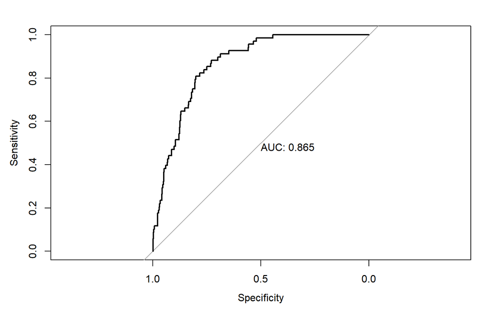

### 3.3.3 Decision Tree - BOTH

Decision Trees are versatile machine learning algorithm that carry out both classification and regression tasks. They are extremely powerful algorithms that can successfully fit complex datasets.

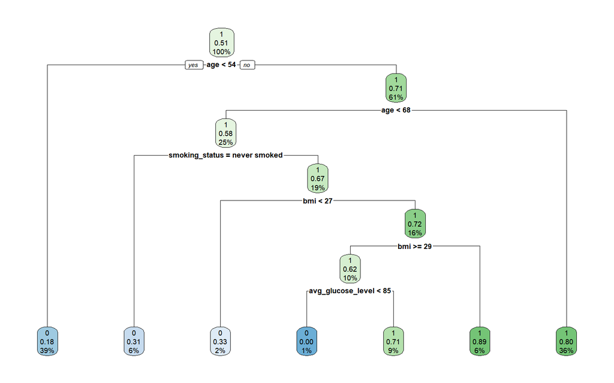

```
## Confusion Matrix and Statistics
##
##           Reference
## Prediction    0    1
##          0 1154   14
##          1  305   54
##
##                Accuracy : 0.791
##                  95% CI : (0.77, 0.811)
##     No Information Rate : 0.955
##     P-Value [Acc > NIR] : 1
##
##                   Kappa : 0.192
##
##  Mcnemar's Test P-Value : <0.0000000000000002
##
##             Sensitivity : 0.791
##             Specificity : 0.794
##          Pos Pred Value : 0.988
##          Neg Pred Value : 0.150
##               Precision : 0.988
##                  Recall : 0.791
##                      F1 : 0.879
##              Prevalence : 0.955
##          Detection Rate : 0.756
##    Detection Prevalence : 0.765
##       Balanced Accuracy : 0.793
##
##        'Positive' Class : 0
##
```

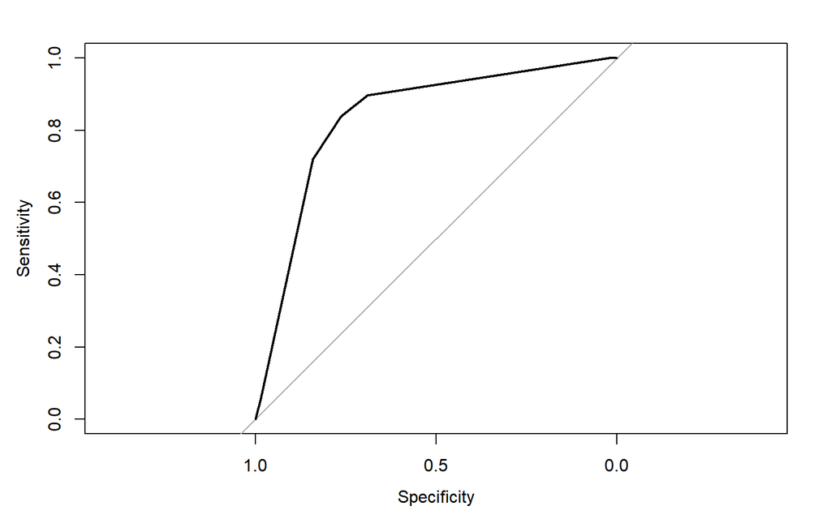

```
## [1] "Area under curve of Decision Tree:  0.836279885497722"
```

### 3.3.4 Decision Tree with Feature Selection - BOTH

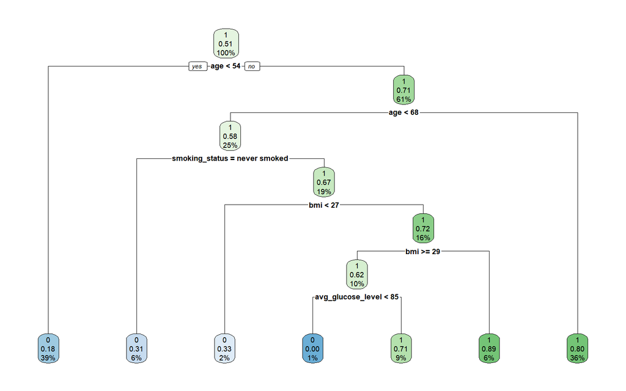

```
## Confusion Matrix and Statistics
##
##           Reference
## Prediction    0    1
##          0 1154   14
##          1  305   54
##
##                Accuracy : 0.791
##                  95% CI : (0.77, 0.811)
##     No Information Rate : 0.955
##     P-Value [Acc > NIR] : 1
##
##                   Kappa : 0.192
##
##  Mcnemar's Test P-Value : <0.0000000000000002
##
##             Sensitivity : 0.791
##             Specificity : 0.794
##          Pos Pred Value : 0.988
##          Neg Pred Value : 0.150
##               Precision : 0.988
##                  Recall : 0.791
##                      F1 : 0.879
##              Prevalence : 0.955
##          Detection Rate : 0.756
##    Detection Prevalence : 0.765
##       Balanced Accuracy : 0.793
##
##        'Positive' Class : 0
##
```

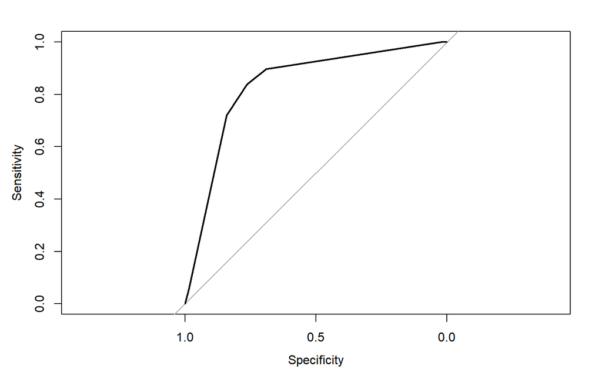

```
## [1] "Area under curve of Decision Tree:  0.836279885497722"
```

### 3.3.5 Tuned Decision Tree - BOTH

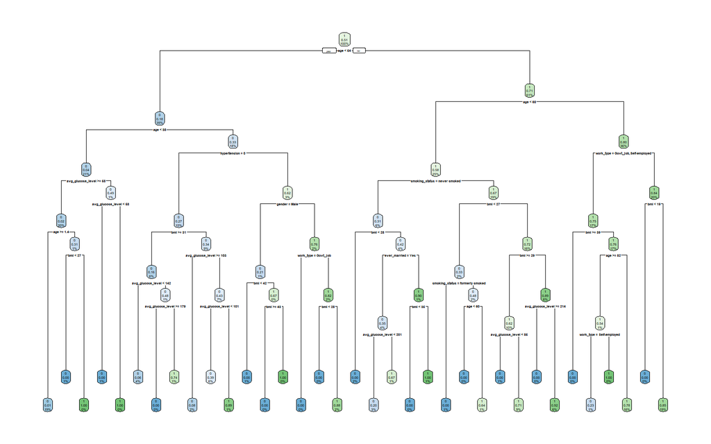

```
## Confusion Matrix and Statistics
##
##           Reference
## Prediction    0    1
##          0 1120   13
##          1  339   55
##
##                Accuracy : 0.769
##                  95% CI : (0.748, 0.79)
##     No Information Rate : 0.955
##     P-Value [Acc > NIR] : 1
##
##                   Kappa : 0.175
##
##  Mcnemar's Test P-Value : <0.0000000000000002
##
##             Sensitivity : 0.768
##             Specificity : 0.809
##          Pos Pred Value : 0.989
##          Neg Pred Value : 0.140
##               Precision : 0.989
##                  Recall : 0.768
##                      F1 : 0.864
##              Prevalence : 0.955
##          Detection Rate : 0.733
##    Detection Prevalence : 0.742
##       Balanced Accuracy : 0.788
##
##        'Positive' Class : 0
##
```

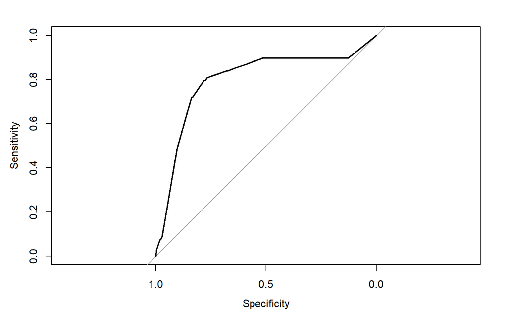

```
## [1] "Area under curve of Decision Tree:  0.798003265733984"
```

### 3.3.6 Tuned Decision Tree with Feature Selection - BOTH

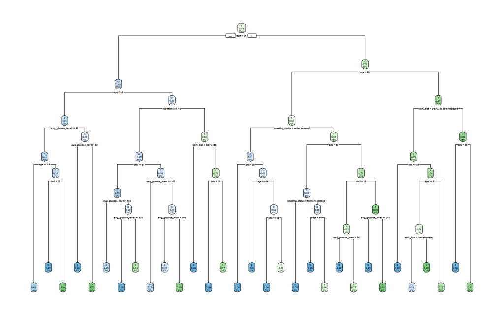

```
## Confusion Matrix and Statistics
##
##           Reference
## Prediction    0    1
##          0 1075   12
##          1  384   56
##
##                Accuracy : 0.741
##                  95% CI : (0.718, 0.762)
##     No Information Rate : 0.955
##     P-Value [Acc > NIR] : 1
##
##                   Kappa : 0.155
##
##  Mcnemar's Test P-Value : <0.0000000000000002
##
##             Sensitivity : 0.737
##             Specificity : 0.824
##          Pos Pred Value : 0.989
##          Neg Pred Value : 0.127
##               Precision : 0.989
##                  Recall : 0.737
##                      F1 : 0.844
##              Prevalence : 0.955
##          Detection Rate : 0.704
##    Detection Prevalence : 0.712
##       Balanced Accuracy : 0.780
##
##        'Positive' Class : 0
##
```

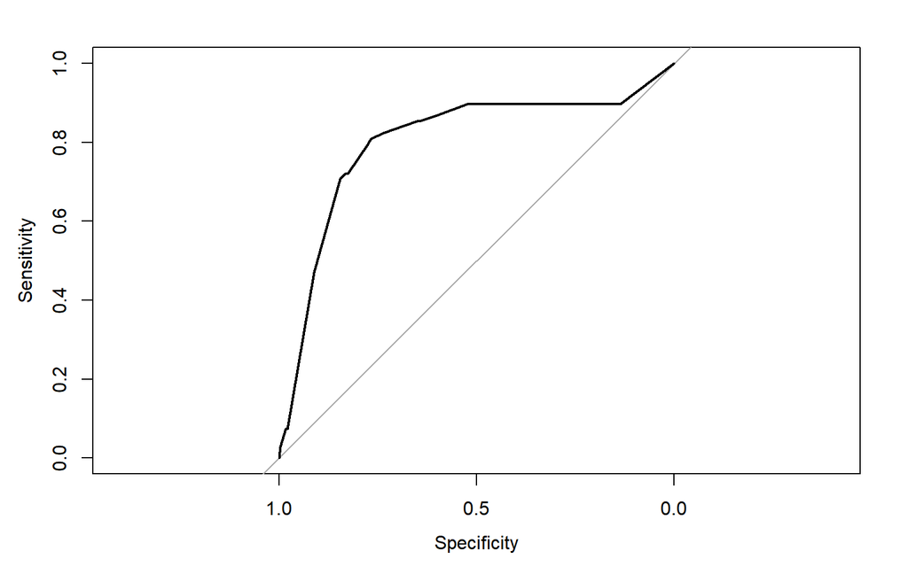

```
## [1] "Area under curve of Decision Tree:  0.801500826512922"
```

### 3.3.7 Random Forest

Random Forest is a collection of decision trees. To obtain more precise predictions, it constructs and merges several decision trees. The classification algorithm is non-linear. When utilized independently, each decision tree model is used.

```
## Confusion Matrix and Statistics
##
##           Reference
## Prediction    0    1
##          0 1382   51
##          1   77   17
##
##                Accuracy : 0.916
##                  95% CI : (0.901, 0.93)
##     No Information Rate : 0.955
##     P-Value [Acc > NIR] : 1.0000
##
##                   Kappa : 0.167
##
##  Mcnemar's Test P-Value : 0.0271
##
##             Sensitivity : 0.947
##             Specificity : 0.250
##          Pos Pred Value : 0.964
##          Neg Pred Value : 0.181
##               Precision : 0.964
##                  Recall : 0.947
##                      F1 : 0.956
##              Prevalence : 0.955
##          Detection Rate : 0.905
##    Detection Prevalence : 0.938
##       Balanced Accuracy : 0.599
##
##        'Positive' Class : 0
##
```

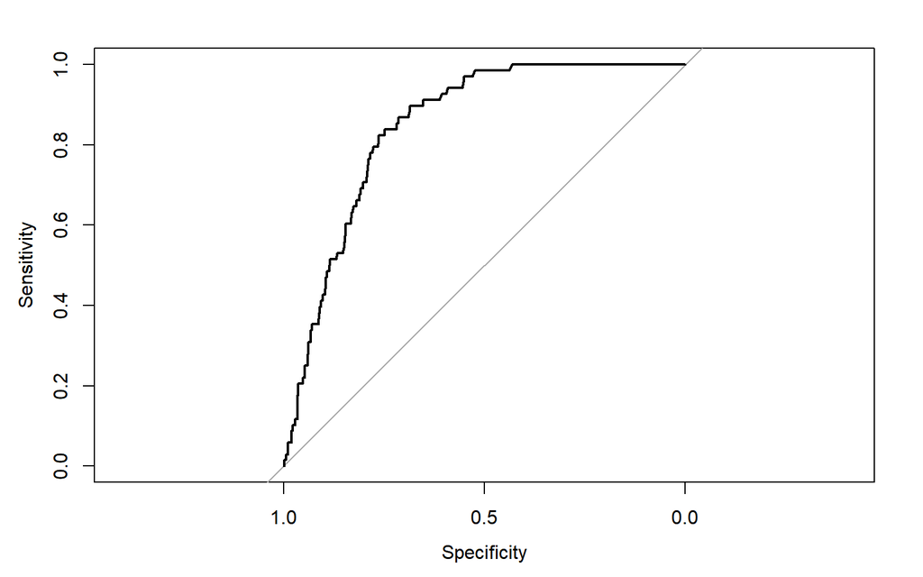

```
## [1] "Area under curve of random forest:  0.846152683143168"
```

### 3.3.8 Random Forest with Feature Selected Variables

```
## Confusion Matrix and Statistics
##
##           Reference
## Prediction    0    1
##          0 1363   46
##          1   96   22
##
##                Accuracy : 0.907
##                  95% CI : (0.891, 0.921)
##     No Information Rate : 0.955
##     P-Value [Acc > NIR] : 1
##
##                   Kappa : 0.191
##
##  Mcnemar's Test P-Value : 0.0000392
##
##             Sensitivity : 0.934
##             Specificity : 0.324
##          Pos Pred Value : 0.967
##          Neg Pred Value : 0.186
##               Precision : 0.967
##                  Recall : 0.934
##                      F1 : 0.950
##              Prevalence : 0.955
##          Detection Rate : 0.893
##    Detection Prevalence : 0.923
##       Balanced Accuracy : 0.629
##
##        'Positive' Class : 0
##
```

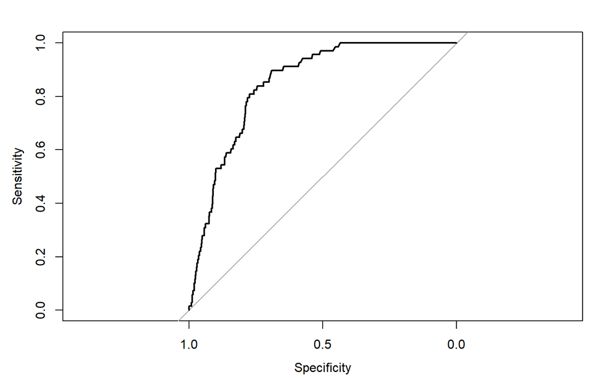

```
## [1] "Area under curve of random forest:  0.848082893198403"
```

## 3.4 ROSE

ROSE is Random Over Sampling Examples. It expands the feature space of minority and majority class examples to provide a sample of synthetic data. Operationally, a conditional kernel density estimate of the two classes is used to generate the new samples.

### 3.4.1 Logistic Regression - ROSE

```
## Confusion Matrix and Statistics
##
##           Reference
## Prediction   0   1
##          0 907   5
##          1 322  43
##
##                Accuracy : 0.744
##                  95% CI : (0.719, 0.768)
##     No Information Rate : 0.962
##     P-Value [Acc > NIR] : 1
##
##                   Kappa : 0.152
##
##  Mcnemar's Test P-Value : <0.0000000000000002
##
##             Sensitivity : 0.738
##             Specificity : 0.896
##          Pos Pred Value : 0.995
##          Neg Pred Value : 0.118
##               Precision : 0.995
##                  Recall : 0.738
##                      F1 : 0.847
##              Prevalence : 0.962
##          Detection Rate : 0.710
##    Detection Prevalence : 0.714
##       Balanced Accuracy : 0.817
##
##        'Positive' Class : 0
##
```

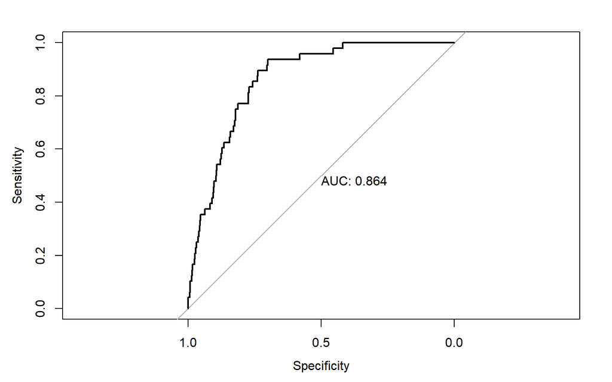

```
##
## Call:
## roc.formula(formula = test1$stroke ~ test_prob, plot = TRUE,     print.auc = TRUE)
##
## Data: test_prob in 1229 controls (test1$stroke 0) < 48 cases (test1$stroke 1).
## Area under the curve: 0.864
```

### 3.4.2 Logistic Regression with Feature Selection - ROSE

```
## Confusion Matrix and Statistics
##
##           Reference
## Prediction   0   1
##          0 907   6
##          1 322  42
##
##                Accuracy : 0.743
##                  95% CI : (0.718, 0.767)
##     No Information Rate : 0.962
##     P-Value [Acc > NIR] : 1
##
##                   Kappa : 0.147
##
##  Mcnemar's Test P-Value : <0.0000000000000002
##
##             Sensitivity : 0.738
##             Specificity : 0.875
##          Pos Pred Value : 0.993
##          Neg Pred Value : 0.115
##               Precision : 0.993
##                  Recall : 0.738
##                      F1 : 0.847
##              Prevalence : 0.962
##          Detection Rate : 0.710
##    Detection Prevalence : 0.715
##       Balanced Accuracy : 0.806
##
##        'Positive' Class : 0
##
```

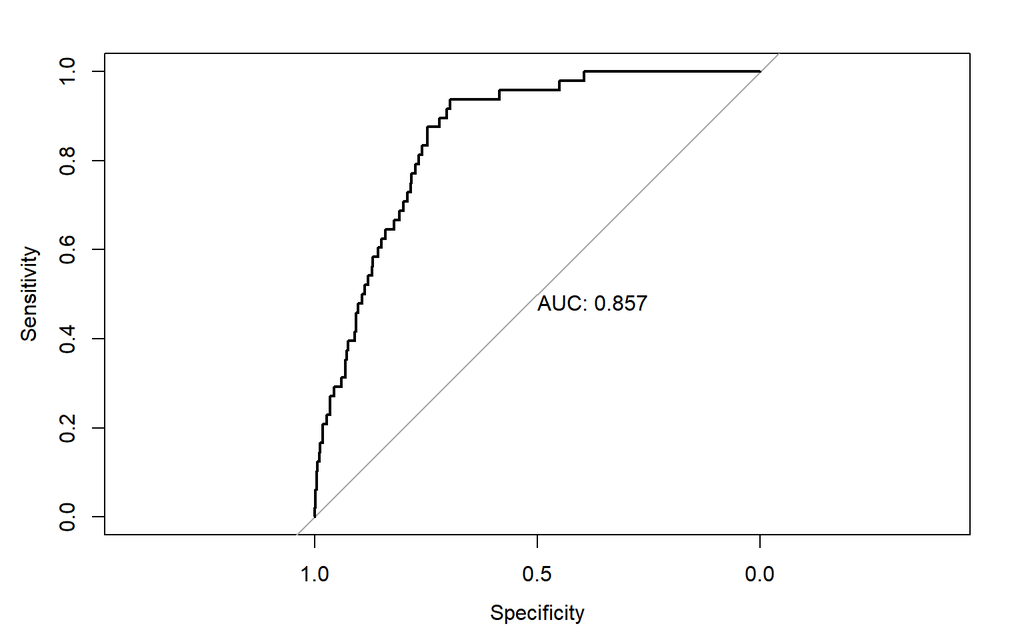

### 3.4.3 DECISION TREE - ROSE

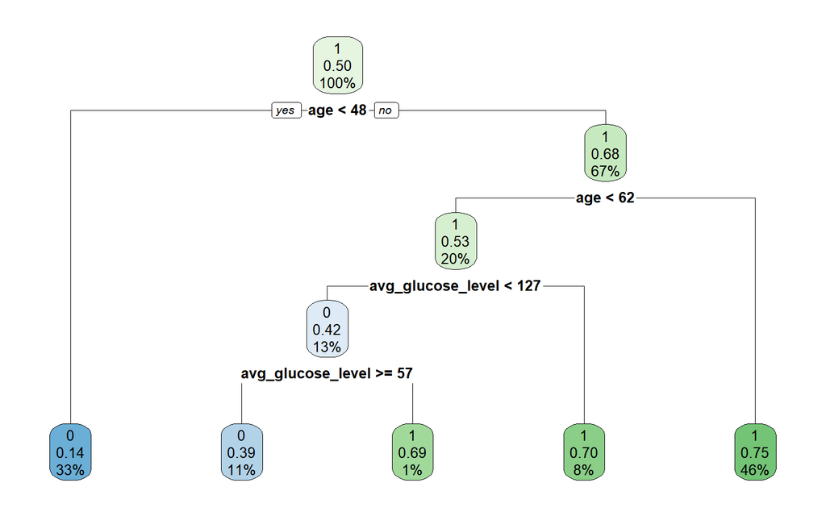

```
## Confusion Matrix and Statistics
##
##           Reference
## Prediction   0   1
##          0 900  10
##          1 329  38
##
##                Accuracy : 0.735
##                  95% CI : (0.709, 0.759)
##     No Information Rate : 0.962
##     P-Value [Acc > NIR] : 1
##
##                   Kappa : 0.125
##
##  Mcnemar's Test P-Value : <0.0000000000000002
##
##             Sensitivity : 0.732
##             Specificity : 0.792
##          Pos Pred Value : 0.989
##          Neg Pred Value : 0.104
##               Precision : 0.989
##                  Recall : 0.732
##                      F1 : 0.842
##              Prevalence : 0.962
##          Detection Rate : 0.705
##    Detection Prevalence : 0.713
##       Balanced Accuracy : 0.762
##
##        'Positive' Class : 0
##
```

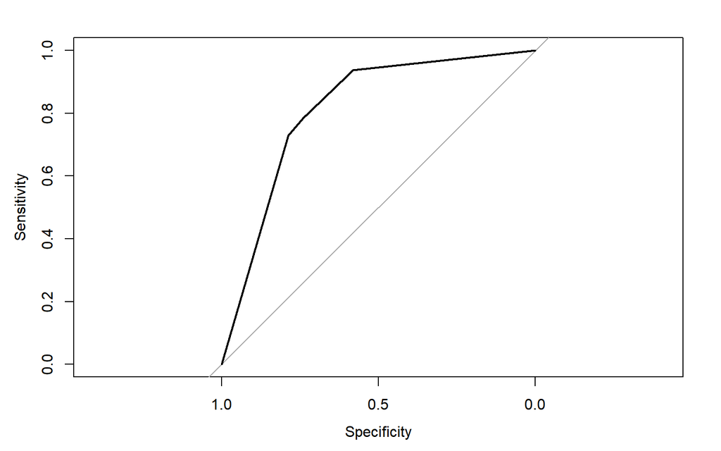

```
## [1] "Area under curve of decision tree:  0.813118727963114"
```

### 3.4.4 DECISION TREE with Feature Selection - ROSE

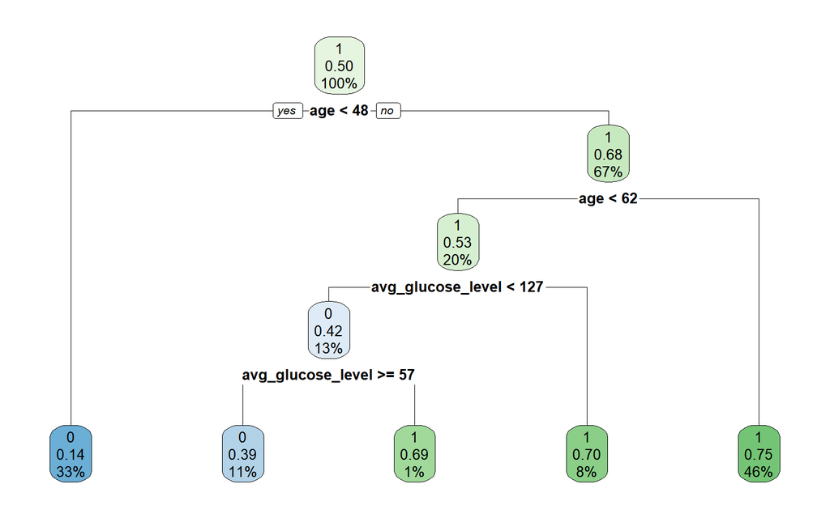

```
## Confusion Matrix and Statistics
##
##           Reference
## Prediction   0   1
##          0 900  10
##          1 329  38
##
##                Accuracy : 0.735
##                  95% CI : (0.709, 0.759)
##     No Information Rate : 0.962
##     P-Value [Acc > NIR] : 1
##
##                   Kappa : 0.125
##
##  Mcnemar's Test P-Value : <0.0000000000000002
##
##             Sensitivity : 0.732
##             Specificity : 0.792
##          Pos Pred Value : 0.989
##          Neg Pred Value : 0.104
##               Precision : 0.989
##                  Recall : 0.732
##                      F1 : 0.842
##              Prevalence : 0.962
##          Detection Rate : 0.705
##    Detection Prevalence : 0.713
##       Balanced Accuracy : 0.762
##
##        'Positive' Class : 0
##
```

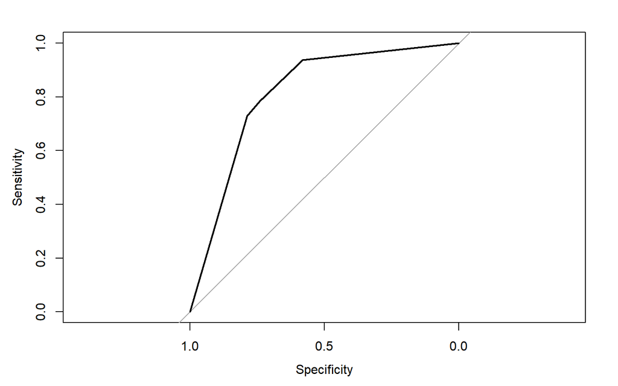

```
## [1] "Area under curve of decision tree:  0.813118727963114"
```

### 3.4.5 Tuned Decision Tree - ROSE

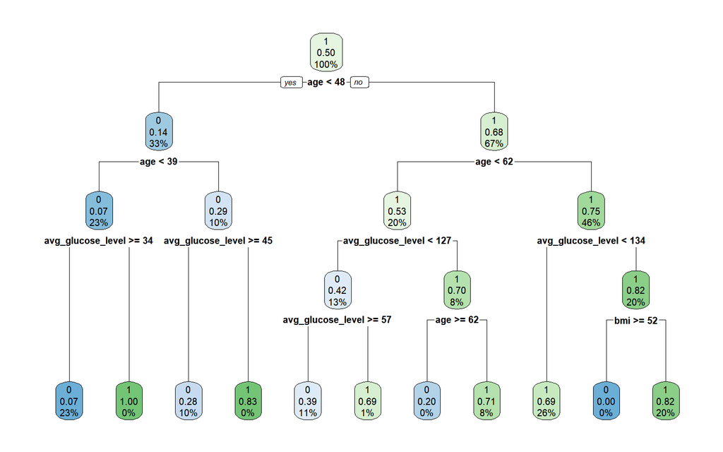

```
## Confusion Matrix and Statistics
##
##           Reference
## Prediction   0   1
##          0 902  10
##          1 327  38
##
##                Accuracy : 0.736
##                  95% CI : (0.711, 0.76)
##     No Information Rate : 0.962
##     P-Value [Acc > NIR] : 1
##
##                   Kappa : 0.126
##
##  Mcnemar's Test P-Value : <0.0000000000000002
##
##             Sensitivity : 0.734
##             Specificity : 0.792
##          Pos Pred Value : 0.989
##          Neg Pred Value : 0.104
##               Precision : 0.989
##                  Recall : 0.734
##                      F1 : 0.843
##              Prevalence : 0.962
##          Detection Rate : 0.706
##    Detection Prevalence : 0.714
##       Balanced Accuracy : 0.763
##
##        'Positive' Class : 0
##
```

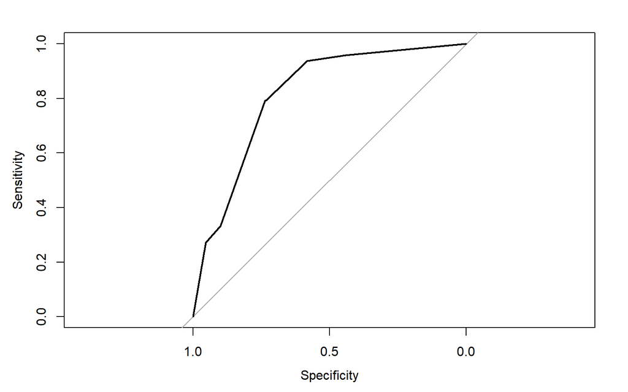

```
## [1] "Area under curve of decision tree:  0.813084825061025"
```

### 3.4.6 Tuned Decision Tree with Feature Selection - ROSE

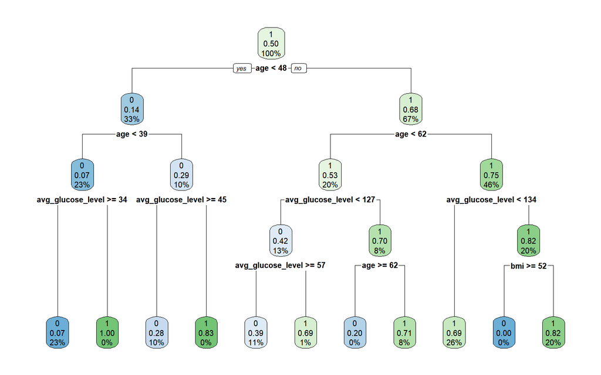

```
## Confusion Matrix and Statistics
##
##           Reference
## Prediction   0   1
##          0 900  10
##          1 329  38
##
##                Accuracy : 0.735
##                  95% CI : (0.709, 0.759)
##     No Information Rate : 0.962
##     P-Value [Acc > NIR] : 1
##
##                   Kappa : 0.125
##
##  Mcnemar's Test P-Value : <0.0000000000000002
##
##             Sensitivity : 0.732
##             Specificity : 0.792
##          Pos Pred Value : 0.989
##          Neg Pred Value : 0.104
##               Precision : 0.989
##                  Recall : 0.732
##                      F1 : 0.842
##              Prevalence : 0.962
##          Detection Rate : 0.705
##    Detection Prevalence : 0.713
##       Balanced Accuracy : 0.762
##
##        'Positive' Class : 0
##
```

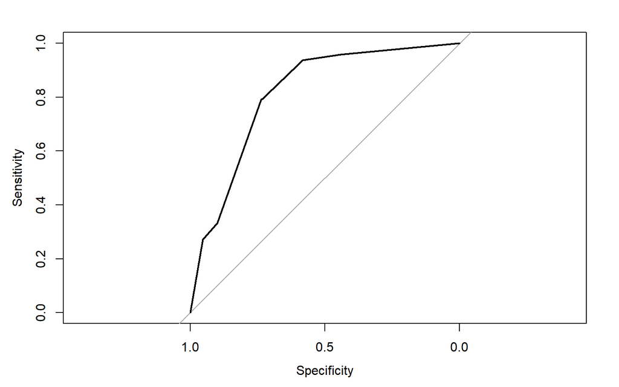

```
## [1] "Area under curve of decision tree:  0.813084825061025"
```

### 3.4.7 Random Forest

```
## Confusion Matrix and Statistics
##
##           Reference
## Prediction   0   1
##          0 974  23
##          1 255  25
##
##                Accuracy : 0.782
##                  95% CI : (0.759, 0.805)
##     No Information Rate : 0.962
##     P-Value [Acc > NIR] : 1
##
##                   Kappa : 0.094
##
##  Mcnemar's Test P-Value : <0.0000000000000002
##
##             Sensitivity : 0.7925
##             Specificity : 0.5208
##          Pos Pred Value : 0.9769
##          Neg Pred Value : 0.0893
##               Precision : 0.9769
##                  Recall : 0.7925
##                      F1 : 0.8751
##              Prevalence : 0.9624
##          Detection Rate : 0.7627
##    Detection Prevalence : 0.7807
##       Balanced Accuracy : 0.6567
##
##        'Positive' Class : 0
##
```

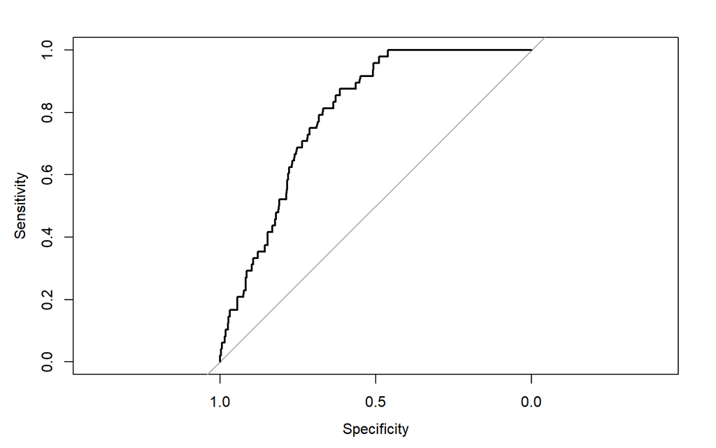

```
## [1] "Area under curve of random forest:  0.794438228912395"
```

### 3.4.8 Random Forest with feature selection

```
## Confusion Matrix and Statistics
##
##           Reference
## Prediction   0   1
##          0 927  17
##          1 302  31
##
##                Accuracy : 0.75
##                  95% CI : (0.726, 0.774)
##     No Information Rate : 0.962
##     P-Value [Acc > NIR] : 1
##
##                   Kappa : 0.104
##
##  Mcnemar's Test P-Value : <0.0000000000000002
##
##             Sensitivity : 0.7543
##             Specificity : 0.6458
##          Pos Pred Value : 0.9820
##          Neg Pred Value : 0.0931
##               Precision : 0.9820
##                  Recall : 0.7543
##                      F1 : 0.8532
##              Prevalence : 0.9624
##          Detection Rate : 0.7259
##    Detection Prevalence : 0.7392
##       Balanced Accuracy : 0.7001
##
##        'Positive' Class : 0
##
```

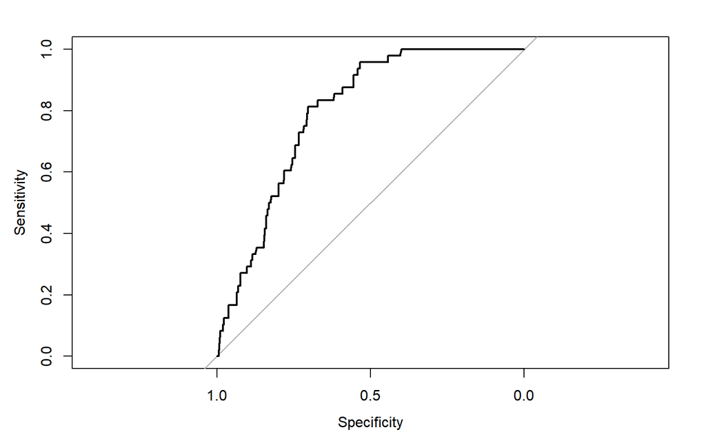

```
## [1] "Area under curve of random forest:  0.794717927854624"
```

# 4 Model Evaluation

As we have seen that this is a medical data, we know that the most important thing to look at is that, the model should not make mistake in predicting if a person has a stroke, i.e in case a person has a stroke and the model predicts that he/she does not have a stroke or vice-versa is very dangerous. Hence, we give more preference to recall than precision.

Here are the possible scenarios that can happen:

• TN – True Negative : When a patient does not have a stroke and model classified them as having no stroke.

• TP – True Positive : When a patient has a stroke and the model classified them as having a stroke.

• FP – False Positive : When a patient who does not have a stroke is classified as a patient having a stroke.

• FN – False Negative : When a Patient who has a stroke but is classified as the person not having a stroke.(Most dangerous case)

As it is clear that the primary focus of this model is to correctly identify the ratio between the number of Positive samples correctly classified as Positive to the total number of Positive samples, which is nothing but our recall

- Recall = TP / (TP + FN)

The next metric that we considered is the accuracy of the model, which is the number of correctly predicted data points out of all the data points.

- Accuracy = (TP + TN) / (TP + TN + FP + FN)

The final metric that we considered to evaluate our model is the AUC-ROC score. As this gives us an idea about how well the model can distinguish between two classes.

# 5 Model Evaluation

We discovered that our model was performing poorly due to a data imbalance issue in the dataset, therefore we decided to balance the data using ROSE and a combination of under and over sampling before modeling. For both balancing techniques, we created three models: Logistic Regression, Decision Tree Classifier, and Random Forest Classifier. Later on, we intended to do feature selection on all of these models based on the Random Forest Classifier’s feature importance plot.

We discovered that the combination of under and oversampling was the most beneficial of the two sampling approaches.

# 6 Conclusion